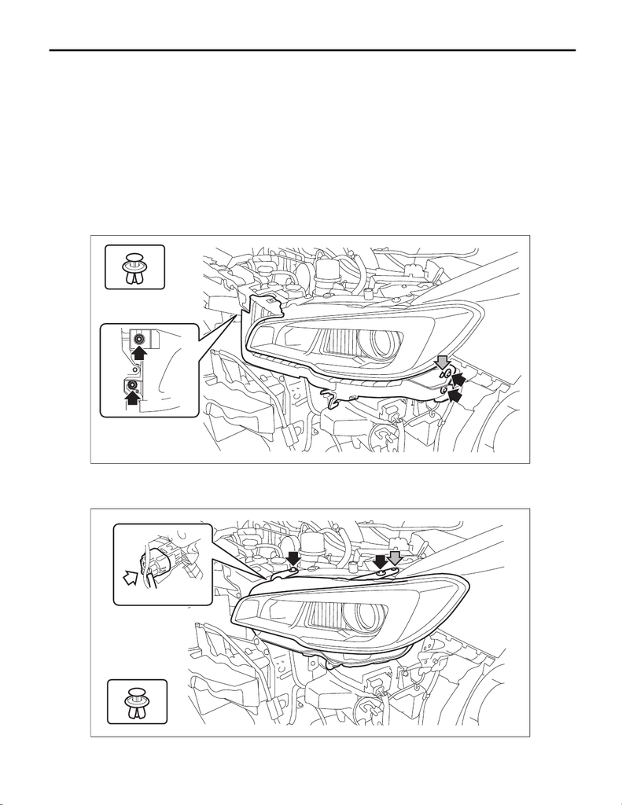

LI-23

Headlight Assembly

LIGHTING SYSTEM

14.Headlight Assembly

A: REMOVAL

CAUTION:

Do not perform work with wet hands, because there is a possibility of electrical shock.

1) Disconnect the ground cable from battery. <Ref. to NT-5, BATTERY, NOTE, Note.>

NOTE:

For models other than STI model, disconnect the ground terminal from battery sensor.

2) Remove the clips and remove the air intake duct. (When removing the headlight RH)

• Except for STI model: <Ref. to IN(w/o STI)-22, REMOVAL, Air Intake Duct.>

• STI model: <Ref. to IN(STI)-11, REMOVAL, Air Intake Duct.>

3) Remove the bumper face - front. <Ref. to EI-30, REMOVAL, Front Bumper.>

4) Remove the bolts and clips, and remove the bracket - front bumper corner.

5) Remove the light assembly - head.

(1) Disconnect the connector.

(2) Remove the bolts and clips, and remove the light assembly - head.

LI-01722

LI-01723

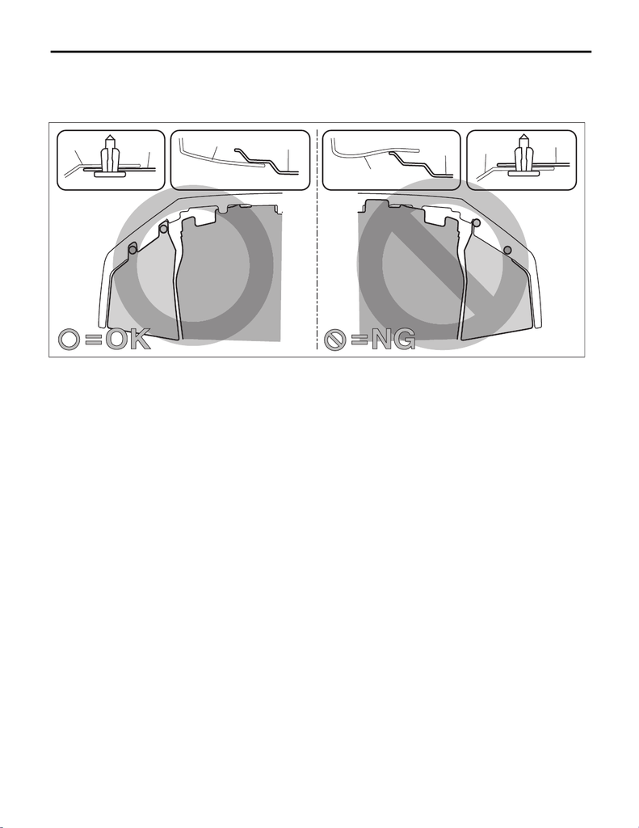

LI-24

Headlight Assembly

LIGHTING SYSTEM

B: INSTALLATION

CAUTION:

• Install the bumper face - front so that the front end of the under cover (b) comes inside the bumper

face - front (a), and the front end of the mud guard (c) comes outside the bumper face - front (a).

• Before installing the bumper face, match the claws on the bracket - front bumper with the engaging

position of flange section on the bumper face side. If the engaging position is not correct, the flange

section may be broken or the clearance between fender panel and bumper face may not be uniform.

1) Install the light assembly - head.

Tightening torque:

7.5 N·m (0.8 kgf-m, 5.5 ft-lb)

2) Install the bracket - front bumper corner.

Tightening torque:

7.5 N·m (0.8 kgf-m, 5.5 ft-lb)

3) Install the bumper face - front. <Ref. to EI-34, INSTALLATION, Front Bumper.>

4) Install the air intake duct. (When the headlight RH was removed)

5) Connect the battery ground terminal. <Ref. to NT-5, BATTERY, NOTE, Note.>

NOTE:

For models other than STI model, connect the ground terminal to battery sensor.

6) Adjust the headlight beam and fog light beam.

• Adjust the headlight beam. <Ref. to LI-26, HEADLIGHT BEAM ADJUSTMENT, ADJUSTMENT, Headlight

Assembly.>

• Adjust the fog light beam. (Model with fog light) <Ref. to LI-43, FOG LIGHT AIMING, ADJUSTMENT, Front

Fog Light Assembly.>

COM00138

(a)

(c)

(b)

(a)

(a)

(c)

(b)

(a)

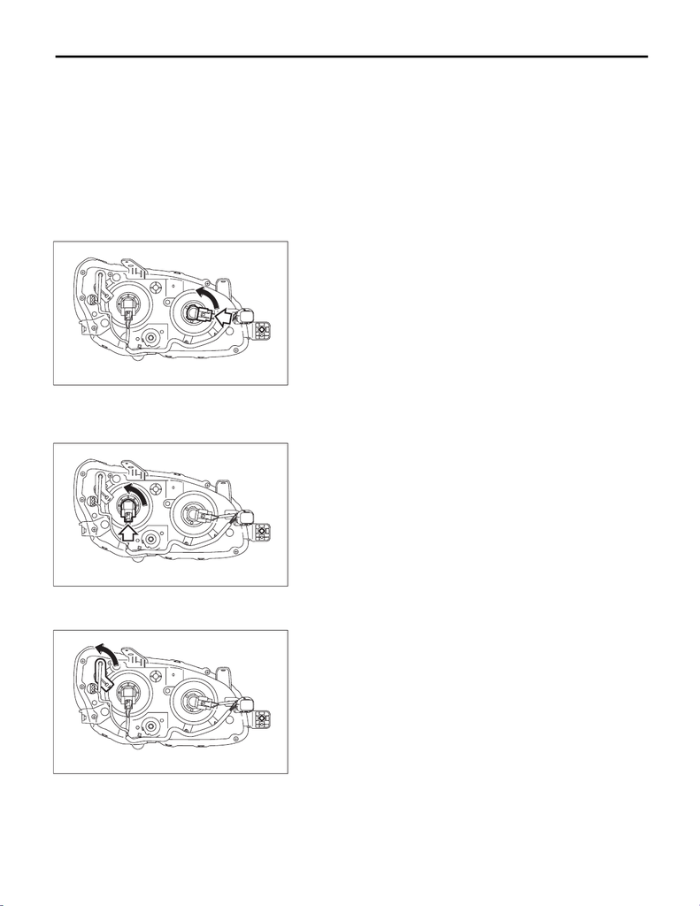

LI-25

Headlight Assembly

LIGHTING SYSTEM

C: DISASSEMBLY

CAUTION:

Use a dry clean cloth so that no grease or water adheres to the glass portion of the bulb.

NOTE:

Since the LED type is a non-disassembled part, it cannot be removed.

1. HIGH BEAM BULB

1) Disconnect the connector.

2) Rotate in the direction of arrow shown in the figure to remove the high beam bulb.

CAUTION:

For the high beam bulb on the RH side, rotate in the opposite direction of arrow shown in the figure.

2. LOW BEAM BULB

1) Disconnect the connector.

2) Rotate in the direction of arrow shown in the figure to remove the low beam bulb.

3. PARKING LIGHT BULB

Rotate the bulb socket in the direction of arrow shown in the figure to remove the parking light bulb.

LI-01733

LI-01734

LI-01735

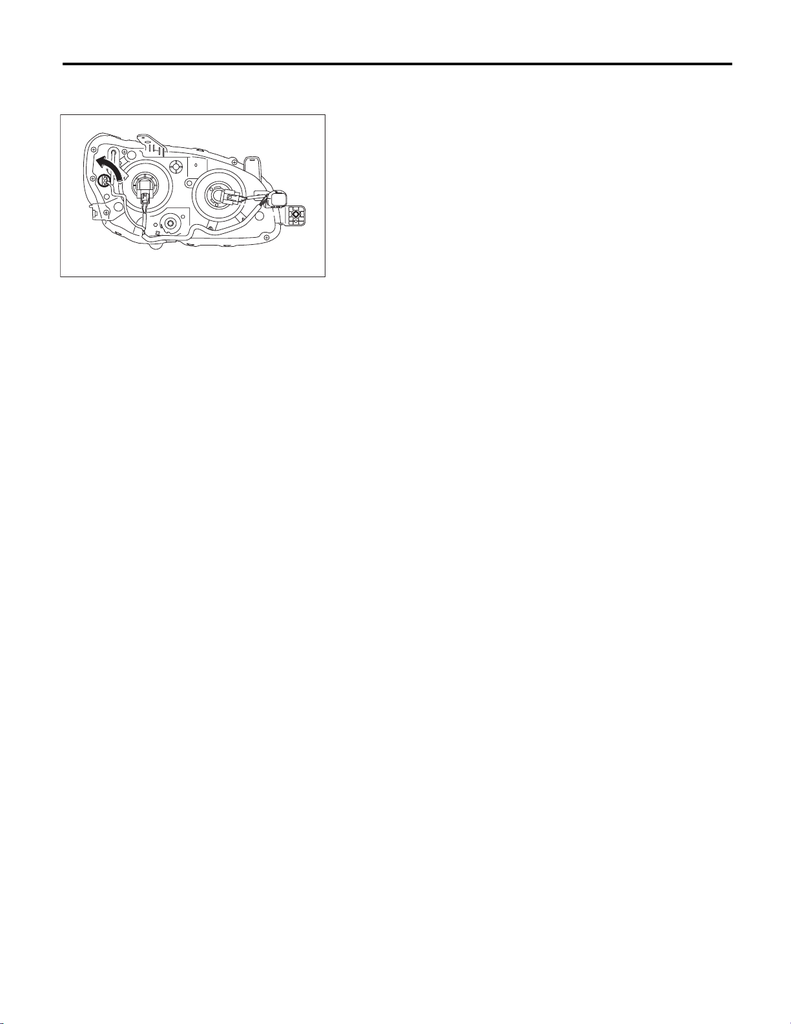

LI-26

Headlight Assembly

LIGHTING SYSTEM

4. SIDE MARKER LIGHT BULB

Rotate the bulb socket in the direction of arrow shown in the figure to remove the side marker light bulb.

D: ASSEMBLY

CAUTION:

Use a dry clean cloth so that no grease or water adheres to the glass portion of the bulb.

1. HIGH BEAM BULB

1) Install the high beam bulb.

2) Connect the connector.

2. LOW BEAM BULB

1) Install the low beam bulb.

2) Connect the connector.

3. PARKING LIGHT BULB

1) Install the parking light bulb.

2) Install the bulb socket.

4. SIDE MARKER LIGHT BULB

1) Install the side marker light bulb.

2) Install the bulb socket.

E: ADJUSTMENT

1. HEADLIGHT BEAM ADJUSTMENT

CAUTION:

• Turn off the light before adjusting the headlight beam level. If it is necessary to inspect the beam

level, do not keep the light on for two minutes or more.

• When blocking the light emitted from the headlight, use a light shield or equivalent.

Do not apply the tape on the lens or place the cloth over it. It may raise the temperature in the light

and cause deformation/bubble formations of the plastic lens.

1) Before checking the headlight beam level, be sure of the following:

• The area around the headlight has not sustained any scratches, damage or other type of deformation.

• The vehicle is parked on a level surface.

• The inflation pressure of tires is correct.

• The vehicle does not have load.

• Vehicle’s fuel tank is fully filled.

2) Set the headlight beam leveler switch to “0” position. (Model with manual leveler)

3) Bounce the vehicle several times to normalize the suspension.

4) Make certain that someone is seated in the driver’s seat.

LI-01736

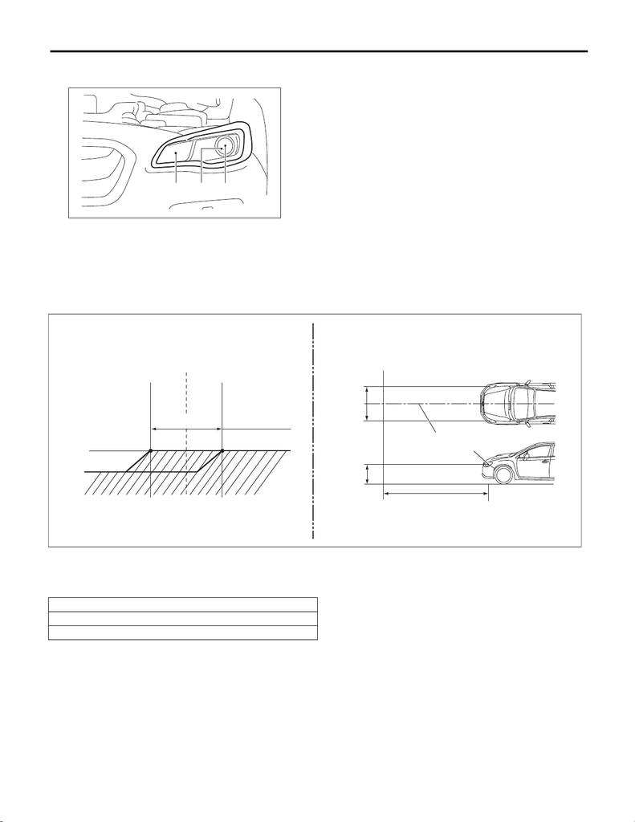

LI-27

Headlight Assembly

LIGHTING SYSTEM

5) Measure the distance of the light source centers and the height of the light source centers for the low

beam.

6) Adjust the headlight beam.

(1) Place the vehicle with the front end facing to the measurement panel, open the front hood, and then

illuminate the low beam.

(a) High beam

(b) Low beam (LED type)

(c) Low beam (halogen type)

LI-01754

(a) (b) (c)

(A) Vehicle center (C) 3 m (10 ft) (D) Height of headlight center

(B) Bulb center marking

W mm (in)

Halogen type: 1,426 (56.14)

LED type: 1,470 (57.87)

LI-01715

W1

W

W2

(A)

(D)

W

W2

W1

(A)

(C)

(B)

(D)

[figure not shown]

LI-28

Headlight Assembly

LIGHTING SYSTEM

(2) Adjust the beam level by turning the aiming screw.

LI-01716